# COGS 118A - Final Project

# Predicting the CCRB's Decision On Complaints from Civilians

## Group Members

- Christian Kim
- Ian Pearson
- Laurensius Junaidy
- Sebastian Algharaballi

# Abstract

Police brutality and abuse of power by law enforcement have been, and still are, extremely contentious issues in the United States, and both have resulted in public distrust and social unrest. The goal of this project is to gain insight into complaints made by civilians living in New York City against police officers. We aim to develop a mathematically-driven system that highlights the significance of organizations like The New York City Civilian Complaint Review Board (CCRB) to ensure police officers are held accountable for their actions. Using data from the CCRB, we will analyze the nature of public complaints and the outcomes of disciplinary actions by wrangling our data, obtaining our most important features, and fitting the best prediction model possible. These steps will be made all in effort to generate correlational patterns within our data that shows us what kinds of complaints are unsubstantiated (the officer in question is not remediated) and substantiaed (the officer is remediated as a result of the investigation). The success of our model will ultimately be measured by its effectiveness in successfully identifying complaints that are substantiated. We will also utilize an F1 score to compute the model’s performance, leading us towards our vision of generalizing these results to combat the rising tension between the general public and law enforcement.

# Background

Police officers being accused of abusing their authority has been a contentious topic in the United States for decades. While this issue has seemingly gained more public attention over the evolution of the social media era, abuse of power by law enforcement has actually been a source of turmoil ever since the beginning of the 20th century. Over a five year period beginning in 2015, more than 11,000 claims or lawsuits were filed against the New York Police Department, alleging some form of police misconduct and several threats to public safety <sup>1</sup>. Of those complaints, more than half of them were solved by some form of a lawsuit. About 530 of those lawsuits were paid out in the amount of up to `$5000`, but most claimants in this group often received less than `$500`. In addition, according to the Commission to Combat Police Corruption’s 20th annual report, just over 11% of New York police officers who should have faced disciplinary action for occupational malpractice walked away with no punishment whatsoever and were able to continue their work in the police force <sup>2</sup>. One research study found that intersecting pathways between police brutality and life-changing health outcomes include 1) fatal injuries that increase population-specific mortality rates, 2) adverse physiological responses that increase morbidity, 3) racist public reactions that cause stress, 4) arrests, incarcerations, and legal, medical, and funeral bills that cause financial strain, and 5) integrated oppressive structures that cause systematic disempowerment <sup>3</sup>. The above issues raise even more importance to our problem, as police brutality on an individual level can have lifelong implications.

Our goal is to gain more insight into the complaints given by civilians against police officers. While developing the scope of our project, we partially took inspiration from a 2019 study conducted by the GBD Police Violence US Subnational Collaborators, a research paper that details unreported police killings across the United States from 1980-2019 <sup>4</sup>. This group found that across all races and states in the USA, 17,100 of the 30,800 deaths from police violence between 1980 and 2018 were unreported by the NVSS (USA National Vital Statistics System). Over this time period, the age-standardized mortality rate due to police violence was highest in non-Hispanic Black people (0.69 [95% CI 0.67–0.71] per 100,000), followed by Hispanic people of any race (0.35 [0.34–0.36]), non-Hispanic White people (0.20 [0.19–0.20]), and non-Hispanic people of other races (0.15 [0.14–0.16]). Besides the eye-opening statistics to further prove the importance of our issue, we aim to achieve this level of transparency and preciseness in our findings regarding applicable police punishment. Moreover, while our project will not directly detail the subject of unreported police killings by race, prior research such as this one gives us more inspiration to extend upon the information that is publicly available, develop a mathematical-driven system that can identify cases where police officers should be remediated for their actions against a civilian, and highlight the significance of organizations like The New York City Civilian Complaint Review Board (CCRB) in an effort to go against the notion of unreported police malpractice. On that note, the CCRB is an independent organization that investigates and recommends viable punishment against New York City police officers accused of abusing their authority through the likes of offensive language, discourtesy, and unnecessary force <sup>5</sup>. Why New York City? Besides being one of the largest cities in America with an immense history of police brutality, New York City is also home to the largest police force on the globe, with over 50,000 active personnel <sup>6</sup>. Therefore, this city’s police department acts as an important role model for other departments, which is why it is of great importance for the NYPD to lead by example and be held accountable when a citizen raises a complaint against one of their officers. Due to this role, the city of New York and the CCRB maintains ongoing, publicly available data regarding official complaints raised to the CCRB that keeps track of poor encounters with police officers in the city. The data includes, but is not limited to, the subject of the complaint, victim age and gender, and, most importantly, the overall punishment the CCRB gave the accused officer.

We will utilize several classification algorithms to find overall patterns and trends between the instances of day-by-day police misconduct detailed in our datasets in an effort to generalize our results and precisely predict whether the CCRB declared a complaint to be substantiated or unsubstantiated. More specifically, we want to be able to obtain a clear understanding between the characteristics of each complaint to determine several baseline criteria that ultimately decides the occupational fate of an officer subject to one of these grievances. We believe that our model will enable us to effectively determine whether or not the CCRB is recommending enough punishment to the “bad apples” of the NYPD, while giving us the opportunity to discover any specific trends or examples of misconduct that tend to lead to more severe punishment for the police officer at hand.

# Problem Statement

To understand whether the Civilian Complaint Review Board (CCRB) recommends appropriate action for NYPD officers accused of abusing their authority, we will first perform an exploratory data analysis to identify underlying patterns and trends in the data. EDA is going to be an essential step for our project, as it helps us to make informed decisions about which features to include in our models. The four models we will utilize for our study are Logistic Regression, K-Nearest Neighbors, the Random Forest Classifier Algorithm, and Gradient Boosting. In order to find and optimize the best-performing model, we will perform feature selection to find and calculate the top 5 features with the most weight for each model. Then, we will implement the `GridSearch` library to determine the best hyperparameters for our algorithms and record the evaluation metrics of precision, recall, and F1 -core of each algorithm to compare model performance. We will value the F1 score as our most important metric due to the calculation providing a good balance of both precision and recall. In our study, we find equal importance in minimizing false positives and false negatives. Falsely classifying a complaint as substantiated could lead to an unfair punishment for the officer in question, and falsely classifying a complaint as unsubstantiated would not provide enough justice for the victim of police malpractice. The F1 score assesses the minimization of both of these scenarios, so it is the most crucial measure in our evaluation process.

After conducting this process, we will have our most optimized and well-understood model that can accurately predict whether the CCRB declared a complaint as substantiated or unsubstantiated, which is described as the recommendation made by the CCRB based on the characteristics of the given complaint. We can compare the predictions made by our highest-scoring model to the actual CCRB recommendations and analyze the discrepancies to determine if there are any consistent patterns or trends in the data that may suggest systematic biases. Furthermore, we can determine which features are found to be the most impactful from the dataset; if these features are discriminatory by nature, it may suggest discrimination within the process. In general, determining and deploying our most successful model could act as a concrete "solution" to this prediction task, but solely relying on a singular model would not necessarily yield an optimal real-world result, as CCRB disposition is a complex and multidimensional task that is far from easy to predict. There could be other existing models that may complement our solution, or even provide better performance than what we find in this study. Therefore, what we define as our "best" model in this study is most likely not the best possible machine learning solution that exists.

We intend to understand exactly how the CCRB punishment categorization is obtained through the likes of our key variables in order to develop an ultimate baseline for police officers to abide by when interacting with the public. These can be seen as guidelines regarding what public actions condemn a reasonable amount of force, what situations call for the need to respect privacy, and when communication between the officer and public offender is the most crucial in order to mitigate the abuse of power. Our comprehensive set of standards can improve the consequences enforced by agencies like the CCRB when condemning police officers who violate these guidelines, thus promoting better accountability and responsible policing.

Another important step in our analysis is to address the issue of systematic bias in the data. One way to counter this is by implementing techniques such as oversampling or undersampling to ensure that each category (substantiated or unsubstantiated) has an equal representation in the dataset. By being mindful of the potential sources of bias in our data and taking steps to address them, we can ensure that our analysis accurately reflects the underlying patterns and trends in the data and provides actionable insights for improving police accountability and responsible policing.

The process above will ultimately guide us towards achieving our goal of determining whether the CCRB is recommending appropriate punishment for NYPD officers accused of abusing their authority. It will also help in the development of a new, system-wide protocol that clearly defines viable actions police officers can perform in a public setting without overstepping the power they possess as law enforcement. Of course, none of this is possible without fitting the best prediction model (with the most appropriate features) to our data at hand and measuring the model’s performance through an F1 score. Only a well-performing model can accurately identify potential biases or injustices in the CCRB's recommendations and use this information to develop a new way of countering police misconduct.

# Data

[NYCLU Misconduct Database](https://www.nyclu.org/en/campaigns/nypd-misconduct-database)

- `AsOfDate`: The last time the complaint was updated in the database
- `AllegationID`: The ID of the recorded allegation
- `LastName`: The last name of the officer
- `FirstName`: The first name of the officer
- `OfficerRace`: The race of the officer
- `OfficerGender`: The gender of the officer
- `OfficerID`: The id of the officer
- `CurrentRank`: The current (abbreviated) rank of the officer
- `CurrentRankLong`: The current (full) rank of the officer
- `CurrentCommand`: The current station of the officer
- `IncidentRank`: The (abbreviated) rank of the officer at the time of the incident
- `IncidentRankLong`: The (full) rank of the officer at the time of the incident
- `IncidentCommand`: The station of the officer at the time of the incident
- `ShieldNo`: The badge number of the officer
- `DaysOnForce`: The number of days the officer had been on duty
- `Status`: The current status of the officer (active duty or retired)
- `LastActive`: The most recent date that the officer was on duty
- `ComplaintID`: The ID of the recorded complaint
- `IncidentDate`: The date of the incident
- `FADOType`: What type of complaint is being filed; E.g. Discourtesy, Offensive Language, Abuse of Authority, etc.
- `Allegation`: What the specific allegation was against the officer
- `CCRBDiposition`: CCRB’s final evaluation of the complaint
- `BoardCat`: Simplified version of CCRB Disposition field
- `PenaltyRec`: Description of CCRB charge recommendation
- `NYPDDisposition`: NYPD final disposition of the complaint
- `PenaltyDesc`: NYPD penalty given to the officer named in the complaint
- `LocationType`: Type of location where the incident took place
- `ContactReason`: Reason why police was contacted
- `ContactOutcome`: Outcome of police-civilian contact
- `IncidentPrecinct`: NYPD precinct where the incident took place
- `ImpactedRace`: Self-reported race/ethnicity of the person impacted in the incident
- `ImpactedGender`: Self-reported gender of the person impacted in the incident
- `ImpactedAge`: Self-reported age of the person impacted in the incident
- `ReceivedDate`: Date on which the CCRB received the complaint
- `CloseDate`: Date on which the CCRB closed/completed the complaint

For our prediction task, we are predicting the `CCRBDisposition` variable; there are 25 different actions that the CCRB can recommend in response to a complaint against an officer. However, the decisions can be boiled down to two different categories: 1) whether a claim was substantiated enough to remediate an officer (i.e. dismissal, legal action) or 2) whether a case could not be made to take action against an officer. Thus, we will binarize our variable by either indicating whether a complaint was substantiated (action was taken against an officer) or unsubstantiated (no action was taken against an officer). This makes the prediction task far simpler for the model.

We believe that the most critical variables include `ContactOutcome`, `Allegation`, and `CurrentRank`. These features highlight the circumstances of the incident in the most influential terms. The actual allegation against the officer and the contact outcome can determine what had specifically occurred during the scenario. The current rank of the officer can influence how much power that officer holds in the precinct, and in turn may imply a safety net.

Regarding missing values, we cannot confirm that our data retains a normal distribution and due to the nature of the data normalization complicates the approach. As a result, when handling missing values within the data, we will be adding a unique input to represent absent information. For numerical variables, we will replace a missing value with NaN. For categorical variables, since we will be implementing one-hot encoding, we will add another index to represent missing values. For example, a categorical variable with 3 possible responses, would have 4 possible indices, where the fourth index represents a missing value for that observation.

```python
# import packages for data cleaning
import pandas as pd
import numpy as np
```

```python
# load dataset
ccrb = pd.read_csv("CCRB Complaint Database Raw 04.20.2021.csv")
ccrb.head()
```

|  | AsOfDate | AllegationID | LastName | FirstName | OfficerRace | OfficerGender | OfficerID | CurrentRank | CurrentRankLong | CurrentCommand | ... | PenaltyDesc | LocationType | ContactReason | ContactOutcome | IncidentPrecinct | ImpactedRace | ImpactedGender | ImpactedAge | ReceivedDate | CloseDate |
| --- | --- | --- | --- | --- | --- | --- | --- | --- | --- | --- | --- | --- | --- | --- | --- | --- | --- | --- | --- | --- | --- |
| 0 | 4/20/2021 | 1119144 | Ruscillo | Taylor | White | Female | 54191 | POF | Police Officer | MTN PCT | ... | NaN | Apartment/house | Report-domestic dispute | No arrest made or summons issued | PCT 018 | Hispanic | Male | 29.0 | 2/15/2021 | 4/9/2021 |
| 1 | 4/20/2021 | 1116090 | Medina | Nelson | Hispanic | Male | 76926 | POM | Police Officer | TB DT02 | ... | NaN | Subway station/train | C/V intervened on behalf of/observed encounter... | Arrest - other violation/crime | PCT 014 | Black | Male | 43.0 | 1/13/2021 | 3/9/2021 |
| 2 | 4/20/2021 | 1116091 | Pierre | Bebeto | Black | Male | 76976 | POM | Police Officer | TB DT02 | ... | NaN | Subway station/train | C/V intervened on behalf of/observed encounter... | Arrest - other violation/crime | PCT 014 | Black | Male | 43.0 | 1/13/2021 | 3/9/2021 |
| 3 | 4/20/2021 | 1115473 | Chapman | John | White | Male | 18497 | POM | Police Officer | 075 PCT | ... | NaN | Apartment/house | Report-domestic dispute | No arrest made or summons issued | PCT 075 | NaN | Male | 57.0 | 1/11/2021 | 3/10/2021 |
| 4 | 4/20/2021 | 1115475 | Tafuro | Justin | White | Male | 19003 | POM | Police Officer | 075 PCT | ... | NaN | Apartment/house | Report-domestic dispute | No arrest made or summons issued | PCT 075 | NaN | Male | 57.0 | 1/11/2021 | 3/10/2021 |

5 rows × 35 columns

```python
# examine all columns in ccrb dataset
ccrb.columns
```

```
Index(['AsOfDate', 'AllegationID', 'LastName', 'FirstName', 'OfficerRace',
       'OfficerGender', 'OfficerID', 'CurrentRank', 'CurrentRankLong',
       'CurrentCommand', 'IncidentRank', 'IncidentRankLong', 'IncidentCommand',
       'ShieldNo', 'DaysOnForce', 'Status', 'LastActive', 'ComplaintID',
       'IncidentDate', 'FADOType', 'Allegation', 'CCRBDisposition', 'BoardCat',
       'PenaltyRec', 'NYPDDisposition', 'PenaltyDesc', 'LocationType',
       'ContactReason', 'ContactOutcome', 'IncidentPrecinct', 'ImpactedRace',
       'ImpactedGender', 'ImpactedAge', 'ReceivedDate', 'CloseDate'],
      dtype='object')
```

```python
# get rid of AsOfDate, AllegationID, LastName, FirstName, ComplaintID, PenaltyRec, NYPDDisposition, PenaltyDesc,
# LocationType, ReceivedDate, CloseDate
ccrb = ccrb.drop(columns = ["AsOfDate", "AllegationID", "LastName", "FirstName", "ShieldNo", "ComplaintID",
                            "PenaltyRec", "NYPDDisposition", "PenaltyDesc", "LocationType", "ReceivedDate",
                            "CloseDate", "IncidentRank", "CurrentRank", "BoardCat", "OfficerID", "LastActive"])

# lowercase all column names and strings in column names
ccrb.columns= ccrb.columns.str.lower()
for column in list(ccrb.columns):
    if type(ccrb[column][0]) == str:
        ccrb[column] = ccrb[column].str.lower()

ccrb.head()
```

|  | officerrace | officergender | currentranklong | currentcommand | incidentranklong | incidentcommand | daysonforce | status | incidentdate | fadotype | allegation | ccrbdisposition | contactreason | contactoutcome | incidentprecinct | impactedrace | impactedgender | impactedage |
| --- | --- | --- | --- | --- | --- | --- | --- | --- | --- | --- | --- | --- | --- | --- | --- | --- | --- | --- |
| 0 | white | female | police officer | mtn pct | police officer | mtn pct | 672 | active | 2/15/2021 | abuse of authority | threat of arrest | complainant unavailable | report-domestic dispute | no arrest made or summons issued | pct 018 | hispanic | male | 29.0 |
| 1 | hispanic | male | police officer | tb dt02 | police officer | tb dt02 | 4753 | active | 1/11/2021 | force | physical force | closed - pending litigation | c/v intervened on behalf of/observed encounter... | arrest - other violation/crime | pct 014 | black | male | 43.0 |
| 2 | black | male | police officer | tb dt02 | police officer | tb dt02 | 924 | active | 1/11/2021 | force | physical force | closed - pending litigation | c/v intervened on behalf of/observed encounter... | arrest - other violation/crime | pct 014 | black | male | 43.0 |
| 3 | white | male | police officer | 075 pct | police officer | 075 pct | 361 | active | 1/1/2021 | discourtesy | word | complaint withdrawn | report-domestic dispute | no arrest made or summons issued | pct 075 | NaN | male | 57.0 |
| 4 | white | male | police officer | 075 pct | police officer | 075 pct | 2733 | active | 1/1/2021 | discourtesy | word | complaint withdrawn | report-domestic dispute | no arrest made or summons issued | pct 075 | NaN | male | 57.0 |

Now, we want to binarize the values in the `ccrbdisposition` column. As mentioned earlier, are 25 different actions that the CCRB can recommend in response to a complaint against an officer. However, the decisions can be boiled down to two different categories: 1) whether a claim was substantiated enough to remediate an officer (i.e. dismissal, legal action) or 2) whether a case could not be made to take action against an officer. Thus, we will binarize our variable by either indicating whether a complaint was substantiated (action was taken against an officer) or unsubstantiated (no action was taken against an officer). Thus, the binarization process is shown below, where substantiated is denoted as 1 and unsubstantiated is denoted as 0.

```python
# binarize the CCRBDisposition column between (0) unsubstantiated and (1) substantiated
# if substantiated, switch to substantiated; if anything else, then unsubstantiated
ccrbDispositionList = list(ccrb["ccrbdisposition"])
for i in range(len(ccrbDispositionList)):
    if "substantiated" in ccrbDispositionList[i] and "unsubstantiated" not in ccrbDispositionList[i]:
        ccrbDispositionList[i] = 1
    else:
        ccrbDispositionList[i] = 0

ccrb["ccrbdisposition"] = ccrbDispositionList
ccrb.head()
```

|  | officerrace | officergender | currentranklong | currentcommand | incidentranklong | incidentcommand | daysonforce | status | incidentdate | fadotype | allegation | ccrbdisposition | contactreason | contactoutcome | incidentprecinct | impactedrace | impactedgender | impactedage |
| --- | --- | --- | --- | --- | --- | --- | --- | --- | --- | --- | --- | --- | --- | --- | --- | --- | --- | --- |
| 0 | white | female | police officer | mtn pct | police officer | mtn pct | 672 | active | 2/15/2021 | abuse of authority | threat of arrest | 0 | report-domestic dispute | no arrest made or summons issued | pct 018 | hispanic | male | 29.0 |
| 1 | hispanic | male | police officer | tb dt02 | police officer | tb dt02 | 4753 | active | 1/11/2021 | force | physical force | 0 | c/v intervened on behalf of/observed encounter... | arrest - other violation/crime | pct 014 | black | male | 43.0 |
| 2 | black | male | police officer | tb dt02 | police officer | tb dt02 | 924 | active | 1/11/2021 | force | physical force | 0 | c/v intervened on behalf of/observed encounter... | arrest - other violation/crime | pct 014 | black | male | 43.0 |
| 3 | white | male | police officer | 075 pct | police officer | 075 pct | 361 | active | 1/1/2021 | discourtesy | word | 0 | report-domestic dispute | no arrest made or summons issued | pct 075 | NaN | male | 57.0 |
| 4 | white | male | police officer | 075 pct | police officer | 075 pct | 2733 | active | 1/1/2021 | discourtesy | word | 0 | report-domestic dispute | no arrest made or summons issued | pct 075 | NaN | male | 57.0 |

# Proposed Solution

As a reminder, our dataset is the `CCRB Complaint Database Raw 04.20.2021.csv` dataset, which was taken from NYCLU’s GitHub under its NYPD Misconduct Complaint Database repository. An important point to note is that there are 35 columns in the dataset and that more than half of them contain string categorical variables. Also, while the “CCRBDisposition” column contains 25 different actions that the CCRB can take to respond to a complaint, these 25 actions can be boiled down to a binary variable of whether a complaint was “Substantiated” (officer was remediated in some sort of way) or “Not Substantiated” (the officer was not remediated), and this binary variable is what we want to predict.

We are not able to reference a benchmark model because there isn't any model that tries to make the predictions that we are striving to make. Since referencing a benchmark model is not appropriate in our case, pivoting to the usage of a baseline mode and using other classifiers would make sense. Given that picking a naive baseline model would result in one of our non-trivial classifier beating the baseline model's F1 score by default, we figured that it would be far more interesting to simply compare the performance of four different classification models. Specifically, for each model, we will select the features that have the most weight in predicting whether a complaint is substantiated or unsubstantiated by using the `Eli5`Python library. The `Eli5` Python library is commonly used to explain feature performance in machine learning models. The library is designed to help users better understand the decision-making process of machine learning algorithms, especially black-box models like the ones we will be working with for this study. Generally speaking, `Eli5` calculates feature importance by permutation importance, which works by randomly permuting the values of each feature and measuring the resulting decrease in the model's performance. Features that cause the largest decrease in performance when permuted are considered to be the most important. For more information about this library, see this link: https://pypi.org/project/eli5/

Our first classification algorithm will be logistic regression. Logistic regression is a suitable algorithm for predicting binary outcomes like ours, and can be used to estimate the probability of a substantiated or unsubstantiated outcome based on our many predictor variables. More specifically, we can use logistic regression to analyze the relationship between our most relevant features and the likelihood of a complaint being substantiated or not. By modeling our outcomes through the use of the `Eli5` Python package, we can determine the most influential variables in predicting our overall outcome, and potentially use that information to generalize to policymakers when it comes to substantiated complaints about the police. Additionally, logistic regression models have the advantage of being relatively easy to interpret, so once feature selection is completed, it should not be very difficult to extract our most important features and utilize those features for our model.

Our second classification algorithm will be K-Nearest Neighbors. In our case, we can use the relevant features mentioned in the dataset (such as the type of complaint, impacted gender, etc.) as input variables and the binary outcome of whether the complaint was substantiated or not as the target variable. Then, we can apply the K-NN algorithm to find the K most similar complaints to a new complaint and predict its outcome based on the labels of those K neighbors. One advantage of using K-NN is that it is a non-parametric algorithm, meaning that it does not make any assumptions about the underlying distribution of the data. This makes it suitable for our complex dataset, where the relationships between the input variables and the target variable may not be straightforward or easy to model using parametric methods such as logistic regression. Another strength of K-NN is its interpretability. Unlike some other machine learning models, such as neural networks or decision trees, K-NN outputs a clear and intuitive decision based on the similarity of the input variables to the training data. This makes it easier to explain the reasoning behind our predictions which is especially important in sensitive domains such as policing. It will be important to carefully tune the value of `K` and the distance metric used to measure similarity to achieve optimal performance of this model.

Our third classification algorithm will be the random forest classifier. In terms of the libraries that would be most relevant to our project, `scikit-learn` has a module called `ensemble`, which contains the random forest classifier algorithm. Furthermore, we will also be using the train_test_split package under `scikit-learn` to split the training data and test data from each other. In terms of what makes a random forest classifier a good choice for our problem, it handles class imbalance and missing values in a different way than our other algorithms. We can utilize balanced subsampling to counter the effects of class imbalance that were described previously, which is a method that can process missing values in our dataset while in the act of training, saving us a lot of time (unlike logistic regression and gradient boosting, where we have to impute or one-hot encode our variables during the preprocessing stage). Random forest classifiers also have fewer hyperparameters for us to tune while still providing interpretable importance scores in regard to our selected features, adding to its efficiency and usefulness when considering how complex our data is.

Our fourth classification algorithm will be gradient boosting. Gradient boosting is another suitable outcome for binary problems, especially since the relationship between our predictor and outcome variables is complex and non-linear. It can arguably handle high-dimensional data in a more efficient way than logistic regression, which will be crucial when it comes to the processing time of our large data set. Similar to logistic regression, we will be able to use this algorithm to process our most important features and analyze the relationship between them and our outcome variable (and, compare these results to what was found using K-NN and logistic regression). We can also use gradient boosting to balance the number of instances belonging to each class. For example, there could be a high number of complaints that are substantiated compared to those that are not, leading to an imbalanced and biased model that is more accurate in predicting the majority class as opposed to the minority class. Gradient boosting can handle this by assigning higher weights to the misclassified instances, leading to a much more accurate and fair model that will better generalize to unseen data.

# Evaluation Metrics

$$\text{Precision} = \frac{\text{True Positive}}{\text{True Positive + False Positive}}$$$$\text{Recall} = \frac{\text{True Positive}}{\text{True Positive + False Negative}}$$

Finally, The F1 score formula can be found below…

$$\text{F1 score} = \frac{2 \times \text{Precision} \times \text{Recall}}{\text{Precision} + \text{Recall}}$$

The detriments of having either a low precision or low recall score also illustrates why both are equally important. Having low precision rate means that we are unnecessarily taking actions against police officers for a complaint that is actually unsubstantiated. On the other hand, having a low recall rate means that we are overlooking a complaint that can be utilized to discipline an officer who abused their authority. Thus, since both precision and recall are equally important to the context of this question, the F1 score, which is a harmonic mean of both metrics, will be utilized.

# Results

We will start off by performing some basic exploratory data analysis for our data. In order to do so, we first the seaborn and matplotlib packages, both of which will be utilized to help visualize our data.

```python
# import libraries
import seaborn as sns
import matplotlib.pyplot as plt
```

```python
# check number of rows and columns in ccrb dataset
ccrb.shape
```

```
(279644, 18)
```

Next, we are curious to examine the different data types that make up the `ccrb`dataframe. Below, we notice that two of the columns, `daysonforce` and `impactedage`, are numeric and the rest are categorical.

```python
# examine the different datatypes of each column
ccrb.dtypes
```

```
officerrace          object
officergender        object
currentranklong      object
currentcommand       object
incidentranklong     object
incidentcommand      object
daysonforce           int64
status               object
incidentdate         object
fadotype             object
allegation           object
ccrbdisposition       int64
contactreason        object
contactoutcome       object
incidentprecinct     object
impactedrace         object
impactedgender       object
impactedage         float64
dtype: object
```

```python
# print the number of unique elements in each variable
print(ccrb.nunique())
```

```
officerrace             5
officergender           2
currentranklong         9
currentcommand        699
incidentranklong        9
incidentcommand       703
daysonforce          9292
status                  2
incidentdate        12858
fadotype                5
allegation            118
ccrbdisposition         2
contactreason          53
contactoutcome         23
incidentprecinct       82
impactedrace            8
impactedgender          6
impactedage           158
dtype: int64
```

From the above output, we can clearly see that the column with the most unique values is the `incidentdate` column. We decided to drop the column as we did not feel it was worth the computational expense of having so many different dates from which to use for our models, especially on the topic of methods such as one-hot encoding and how we can easily see a massive vector of size 12,859 for the 12,858 different dates (and one more element to represent a missing date). Thus, we dropped this feature as shown below.

```python
ccrb = ccrb.drop(columns = ["incidentdate"])
ccrb.head()
```

|  | officerrace | officergender | currentranklong | currentcommand | incidentranklong | incidentcommand | daysonforce | status | fadotype | allegation | ccrbdisposition | contactreason | contactoutcome | incidentprecinct | impactedrace | impactedgender | impactedage |
| --- | --- | --- | --- | --- | --- | --- | --- | --- | --- | --- | --- | --- | --- | --- | --- | --- | --- |
| 0 | white | female | police officer | mtn pct | police officer | mtn pct | 672 | active | abuse of authority | threat of arrest | 0 | report-domestic dispute | no arrest made or summons issued | pct 018 | hispanic | male | 29.0 |
| 1 | hispanic | male | police officer | tb dt02 | police officer | tb dt02 | 4753 | active | force | physical force | 0 | c/v intervened on behalf of/observed encounter... | arrest - other violation/crime | pct 014 | black | male | 43.0 |
| 2 | black | male | police officer | tb dt02 | police officer | tb dt02 | 924 | active | force | physical force | 0 | c/v intervened on behalf of/observed encounter... | arrest - other violation/crime | pct 014 | black | male | 43.0 |
| 3 | white | male | police officer | 075 pct | police officer | 075 pct | 361 | active | discourtesy | word | 0 | report-domestic dispute | no arrest made or summons issued | pct 075 | NaN | male | 57.0 |
| 4 | white | male | police officer | 075 pct | police officer | 075 pct | 2733 | active | discourtesy | word | 0 | report-domestic dispute | no arrest made or summons issued | pct 075 | NaN | male | 57.0 |

We use the `describe` function in Python to examine summary statistics of the numeric columns that make up the `ccrb` dataset. Considering that the `describe` function only examines summary statistics for numeric columns, the output shown below for the `daysonforce` and `impactedage` columns is quite straightforward. However, we notice that the `impactedage` column, which represents the column of each complainant's age, has a value over 200. We may need to take a close eye into this situation and find a way to handle this excessive case, since the oldest person in the world is currently 116 years old.

```python
# ccrb EDA again to check changes in values
ccrb.describe()
```

|  | daysonforce | ccrbdisposition | impactedage |
| --- | --- | --- | --- |
| count | 279644.000000 | 279644.000000 | 156588.000000 |
| mean | 2627.786500 | 0.070715 | 30.919132 |
| std | 2254.099378 | 0.256348 | 96.703392 |
| min | -43281.000000 | 0.000000 | -7091.000000 |
| 25% | 1043.000000 | 0.000000 | 23.000000 |
| 50% | 2140.000000 | 0.000000 | 30.000000 |
| 75% | 3931.000000 | 0.000000 | 41.000000 |
| max | 14658.000000 | 1.000000 | 222.000000 |

Since the `daysonforce` column is numeric, we are curious to examine the distribution of the values that represent the range of values that make up the number of days that officers who have complaints against them have been in the police force. Below, we use a seaborn histplot to examine the distribution a little further.

```
[Text(0.5, 0, 'Days on Police Force')]
```

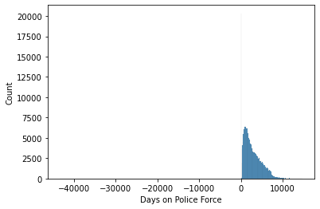

```python
sns.histplot(data = ccrb, x = "daysonforce").set(xlabel = "Days on Police Force")
```

We notice immediately that the plot also take into account negative values, which means that there are negative values in our `daysonforce` column. Having a negative value represent the number of days that a police officer has been on the police force is odd, so we want to consider options as to how we will address this issue. Firstly, we want to see how many of the rows have negative values in the `daysonforce` column, which can be shown below.

```python
# number of rows that have values < 0 for daysonforce column
ccrb[ccrb["daysonforce"] < 0].shape[0]
```

```
147
```

Since there are hundreds of thousands of rows, dropping less than 200 rows will have a menial effect on the performance of the model. While some sort of an imputation method was considered, imputation was ultimately thrown out because of how we couldn't assume that the `daysonforce` column is normally distributed, since imputation on numeric data through mean or mode will influence the performance of the classifiation models. Thus, we chose to drop all rows with `daysonforce` values less than 0.

```
[Text(0.5, 0, 'Days on Police Force')]
```

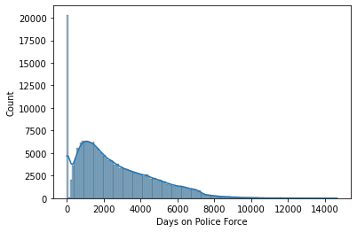

```python
# get rid of rows with daysonforce values less than 0
# display seaborn histplot of distribution of daysonforce column
ccrb = ccrb.drop(ccrb[ccrb["daysonforce"] < 0].index)
sns.histplot(data = ccrb, x = "daysonforce", kde = "True").set(xlabel = "Days on Police Force")
```

On a similar note, since the `impactedage` column is numeric, we are curious to examine the distribution of the values that represent the range of values that make up the ages of the complainants. Below, we use a seaborn histplot to examine the distribution a little further.

```
[Text(0.5, 0, 'Age of the Impacted Complainant')]
```

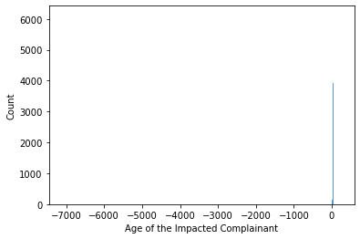

```python
# seaborn histplot of distribution of impactedage column
sns.histplot(data = ccrb, x = "impactedage").set(xlabel = "Age of the Impacted Complainant")
```

Similar to the `daysonforce` column, we immediately notice that there appear to be negative values present when representing values in the `impactedage` column, which illustrates the number of days that the officer to whom the complaint is targetted has been on the Police Force. According to the NYCLU, negative values in this case can account for a variety of reasons, including data entry errors, ambiguous or missing date of birth, and alleged misconduct occurring before the complainant's birth. The problem on our end is that we can't assume what reason each individual has regarding why they have a negative value for the number of days that they have been on the police force. In order to make a decision regarding how we deal with negative values, we take note of the fact that less than 200 rows in the `ccrb` dataset have negative values for the `impactedage` column. However, we also know that there are extrememley high values that were utilized to represent the ages of people. We notice that there are only two rows that have age values greater than 116. So, we decided to drop the two rows, since dropping two rows out of hundreds of thousands of remaining rows will have almost no effect on the model.

```python
# examine number of rows with impactedage values > 116
ccrb[ccrb["impactedage"] > 116].shape[0]
```

```
2
```

```python
# examine number of rows with impactedage values < 0
ccrb[ccrb["impactedage"] < 0].shape[0]
```

```
91
```

Thus, we removed the rows with values in the `impactedage` column that are greater than 116 or less than 0. This change was conducted with the code below.

```
[Text(0.5, 0, 'Age of the Impacted Complainant')]
```

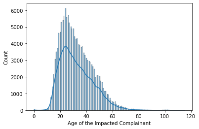

```python
# drop rows with impactedage values < 0 or > 116 and display histogram distribution
ccrb = ccrb.drop(ccrb[ccrb["impactedage"] < 0].index)
ccrb = ccrb.drop(ccrb[ccrb["impactedage"] > 116].index)
sns.histplot(data = ccrb, x = "impactedage", kde = True).set(xlabel = "Age of the Impacted Complainant")
```

Therefore, our EDA process illustrates that the data cleaning process still occurs at the exploratory stage when peculiar instances of data must be addressed. We provided the summary statistics once again for the two numeric columns to showcase the slight difference that occurred as a result of dropping rows based on the reasons outlined above.

```python
# summary statistics for numeric columns in ccrb dataset
ccrb.describe()
```

|  | daysonforce | ccrbdisposition | impactedage |
| --- | --- | --- | --- |
| count | 279404.000000 | 279404.000000 | 156413.000000 |
| mean | 2647.787902 | 0.070754 | 32.693286 |
| std | 2060.123449 | 0.256414 | 12.360201 |
| min | 0.000000 | 0.000000 | 0.000000 |
| 25% | 1044.000000 | 0.000000 | 23.000000 |
| 50% | 2141.000000 | 0.000000 | 30.000000 |
| 75% | 3932.000000 | 0.000000 | 41.000000 |
| max | 14658.000000 | 1.000000 | 115.000000 |

Next, we separated the categorical columns from the numeric columns by keeping column names into two different lists. However, the `ccrbdisposition` column was not counted as a categorical column because we only wanted to include features into these two lists; as a reminder, we are predicting a binarized version of the `ccrbdisposition` column. We created a Cross-Tabulation Table that will show a list of unique values for each feature coupled with a list of the number of occurrences of that value. This allows us to get a better understanding of what values may arise within the dataset, and if there is a skew within the variables. For example, when looking at the values for IncidentRankLong, we can see that 192,825 of the values in this feature are for police officers. This suggests that most of the complaints within the dataset are filed against a lower ranking officer.

```python
# put categorical columns in categoricalColumnsList and numeric columns in numericColumnsList
categoricalColumnsList, numericColumnsList = [], []
for column in ccrb.columns:
    if ccrb[column].dtype == "object":
        categoricalColumnsList += [column]
    else:
        numericColumnsList += [column]

# create cross tabulation table for all categorical columns
for column in categoricalColumnsList:
    print(f"\n---Cross-Tabulation Table for {column}---")
    print(pd.crosstab(index = ccrb[column], columns = 'count'))
```

```
---Cross-Tabulation Table for officerrace---
col_0             count
officerrace
american indian     254
asian              8148
black             38688
hispanic          62808
white            169506

---Cross-Tabulation Table for officergender---
col_0           count
officergender
female          21872
male           257532

---Cross-Tabulation Table for currentranklong---
col_0                    count
currentranklong
captain                   4112
chiefs and other ranks    1700
deputy inspector          2075
detective                78482
inactive ranks               2
inspector                 1537
lieutenant               25469
police officer          110466
sergeant                 55561

---Cross-Tabulation Table for currentcommand---
col_0           count
currentcommand
001 det           265
001 pct           933
005 det           211
005 pct           699
006 det           164
...               ...
warrsec          6837
wtc cmd           380
yth div            14
```

[output cut: 174 more lines]

```
hispanic         36116
other race        4190
refused           1654
unknown          13391
white            20051

---Cross-Tabulation Table for impactedgender---
col_0                   count
impactedgender
female                  38655
gender non-conforming      15
male                   129189
not described             554
transman (ftm)             14
transwoman (mtf)           55
```

Now, we want to perform some correlation analysis among our variables. First, we want to examine the correlation of the two numeric variables in our `ccrb` dataset, `daysonforce` and `impactedage`. Below, we have a pairplot from the `seaborn` package that outlines the plots to showcase the correlation between the two variables.

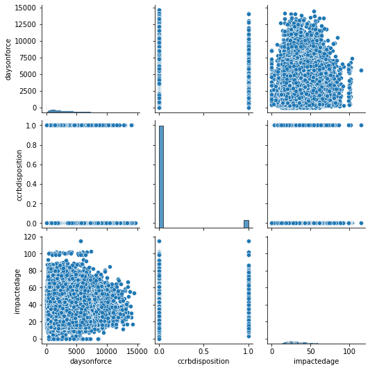

```python
# pairplot for daysonforce and impactedage variables
sns.pairplot(ccrb, diag_kind = "hist")
```

Above, the scatterplots are quite messy and don't reveal anything at facevalue. Furthermore, the histograms are the exact ones that we have seen early on. So, we want to instead further examine the correlation coefficient values between `daysonforce` and `impactedage` using a heatmap. Since `ccrbdisposition` was binarized in such a way that its numerical values would be displayed in the heatmap, the `ccrbdisposition` column is also shown below. Below, we have the the correlation heatmap that showcases the correlation values.

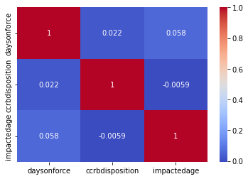

```python
# correlation heatmap for daysonforce and impactedage variables
sns.heatmap(ccrb.corr(), cmap = "coolwarm", annot = True)
```

We see that the correlation coefficient value for `daysonforce` and `impactedage` is 0.058. This idea implies that while we do see a positive correlation between the two variables, they aren't necessarily causal. Furthermore, we can also get an idea of the correlation between the `ccrbdisposition` column and the `impactedage` and `daysonforce` For instance, we notice that there is a positive correlation value of 0.022 between `ccrbdisposition` and `daysonforce`.

Now, we want to be able to examine the correlation between the categorical columns. This task is quite tricky because we need to be able to utilize the string values in the categorical columns to showcase correlation among each other. So, we convert the column names into numeric codes and then use a Pearson correlation to examine the correlation among the different categorical columns. Thus, the correlation coefficient values can be seen below.

```python
# numeric codes for each categorical variable name
ccrbCopy = ccrb.copy(deep = True)
for column in categoricalColumnsList:
    ccrbCopy[column], _ = pd.factorize(ccrb[column])

# create the correlation matrix
corrMatrix = ccrbCopy.corr(method = "pearson")
print(corrMatrix)
```

```
                  officerrace  officergender  currentranklong  currentcommand  \
officerrace          1.000000      -0.111181        -0.106869       -0.082748
officergender       -0.111181       1.000000         0.070205        0.018573
currentranklong     -0.106869       0.070205         1.000000        0.159333
currentcommand      -0.082748       0.018573         0.159333        1.000000
incidentranklong    -0.031409       0.047646         0.474886        0.011255
incidentcommand      0.042034       0.015945        -0.008046        0.128701
daysonforce         -0.002858       0.030363         0.120381       -0.043703
status              -0.157836       0.026813        -0.010969        0.194347
fadotype            -0.037576      -0.003257        -0.037398        0.030576
allegation          -0.141107       0.017553         0.108145        0.197528
ccrbdisposition      0.000732       0.006575         0.010135        0.000252
contactreason       -0.102670       0.017352         0.018216        0.109992
contactoutcome      -0.027759       0.006914        -0.012829        0.026116
incidentprecinct     0.030399      -0.008184        -0.037545       -0.014932
impactedrace         0.098669      -0.031079        -0.092661       -0.150950
impactedgender       0.125256      -0.098621        -0.085414       -0.158525
impactedage         -0.002011      -0.039605        -0.027502       -0.035483

                  incidentranklong  incidentcommand  daysonforce    status  \
officerrace              -0.031409         0.042034    -0.002858 -0.157836
officergender             0.047646         0.015945     0.030363  0.026813
currentranklong           0.474886        -0.008046     0.120381 -0.010969
currentcommand            0.011255         0.128701    -0.043703  0.194347
incidentranklong          1.000000         0.212055     0.612856 -0.041275
incidentcommand           0.212055         1.000000     0.246657 -0.031449
daysonforce               0.612856         0.246657     1.000000  0.094728
status                   -0.041275        -0.031449     0.094728  1.000000
fadotype                 -0.106910        -0.069873    -0.068911  0.122107
allegation               -0.222043        -0.242854    -0.257161  0.437140
ccrbdisposition           0.029397         0.015370     0.022202 -0.013363
contactreason             0.038375        -0.173425    -0.025888  0.307111
contactoutcome            0.000594        -0.066177    -0.047464  0.084083
incidentprecinct          0.157049         0.145528     0.145886 -0.063950
impactedrace              0.147866         0.197481     0.206239 -0.339404
impactedgender            0.163446         0.191980     0.214910 -0.324015
impactedage               0.011639        -0.038807     0.057510 -0.019851

                  fadotype  allegation  ccrbdisposition  contactreason  \
officerrace      -0.037576   -0.141107         0.000732      -0.102670
```

[output cut: 39 more lines]

```
currentranklong        -0.085414    -0.027502
currentcommand         -0.158525    -0.035483
incidentranklong        0.163446     0.011639
incidentcommand         0.191980    -0.038807
daysonforce             0.214910     0.057510
status                 -0.324015    -0.019851
fadotype               -0.031446    -0.021584
allegation             -0.562904     0.003787
ccrbdisposition        -0.018905    -0.005905
contactreason          -0.399023     0.023160
contactoutcome         -0.100722    -0.103919
incidentprecinct        0.078621    -0.003446
impactedrace            0.549953     0.119249
impactedgender          1.000000     0.112584
impactedage             0.112584     1.000000
```

Since we converted the categorical variables into numeric codes, we are able to utilize a method that is normally reserved for continuous variables. The correlation coefficient values from above range from -1 to +1, where -1 indicates a perfect negative correlation and +1 indicates a negative correlation. For instance, we can see that `contactoutcome`, which we predicted to be a critical variable, and `ccrbdisposition` have a correlation coefficient value of -0.025694, which implies a negative relationship. One important note to keep in mind is that because we are attempting to use a Pearson correlation on categorical variables, the interpretation of correlation coefficients in this case is merely limited to linear relationships. While categorical variables can have other types of relationships, like nonlinear, the correlation coefficients above won't be able to catch those relationships.

The EDA process has also revealed that our dataset is very large. In addition, we understand that the dataset will continue to grow even more as we one-hot encode our categorical variables, leading to additional columns that represent each possible level of that categorical variable (such as the `impactedrace` variable having several subcategories of races that will individually be encoded as its own column). This may lead to painfully slow processing times when running our model and feature selection tasks. Therefore, we decided to run a Principal Component Analysis (PCA) on our current data in order to reduce the size of the data set while preserving as much of the original variation as possible. Our PCA code can be found in the supplementary notebook titled `PCA_Exploration.ipynb`, which was included in the repository.

The PCA algorithm generates new column names for the entire dataset, which correspond to the principal components themselves (i.e., "PC1", "PC2", etc.). These new columns represent linear combinations of the original features that capture the most variance in the data. In general, it's not possible to directly interpret the principal components in terms of the original features, since they are not just simple combinations of the original features. Therefore, our PCA dataset does not include a concrete `ccrbdisposition` column that can be used during model training to achieve our substantiation prediction. So, while we were able to generate a transformed, smaller dataset (with the shape of 156,413 x 1250), the cost of using a PCA dataset with zero concrete variables that could be interpreted in a meaningful way outweighed the benefits of reducing the dataset size. As a result, we decided to not include PCA in this notebook.

### Model #1: Logistic Regression

Now, we move onto our first model, which is the logistic regression. Below, we import the necessary packages for the logistic regression and for splitting data between training and testing.

```python
# import packages and split testing from train
from sklearn.model_selection import train_test_split
from sklearn.metrics import confusion_matrix
from sklearn.linear_model import LogisticRegression
from sklearn.ensemble import GradientBoostingClassifier
from sklearn.ensemble import RandomForestClassifier
import eli5
from eli5.sklearn import PermutationImportance
```

When doing our Logistic regression initially with the dataset we got after the cleaning process, we calculated `nan` values for precision, recall, and F1 score. From our investigation, it appeared that labelling a `substantiated` decision with the value 1 and `unsubstantiated` decision with the value 0 caused issues with calculating precision, recall, and F1 score. So, the code below changes 1 values to `substantiated` and 0 values to `unsubstantiated`, just for the Logistic Regression model.

```python
# change 1 to "substantiated" and 0 to "substantiated"
ccrb_logistic = ccrb.copy(deep = True)
logistic_ccrb = list(ccrb_logistic["ccrbdisposition"])
for i in range(len(logistic_ccrb)):
    if logistic_ccrb[i] == 1:
        logistic_ccrb[i] = "substantiated"
    else:
        logistic_ccrb[i] = "unsubstantiated"

ccrb_logistic["ccrbdisposition"] = logistic_ccrb
```

In the below cell we create the first model for the project. In this first iteration, we are able to work on the feature selection process and determine some of the most influential features. We then select the portions of the dataset that we will be using for the model; the `X` variable is all features that the model is considering when making the decision; the `y` variable is the binarized `ccrbDisposition`, the variable that the model will be predicting.

```python
ccrb_logistic_eli5 = pd.get_dummies(ccrb_logistic, columns = categoricalColumnsList)
ccrb_logistic_eli5['impactedage'] = ccrb_logistic_eli5['impactedage'].fillna(0)

# Split the data into training and testing sets
X = ccrb_logistic_eli5.drop(columns = ["ccrbdisposition"])
y = ccrb_logistic_eli5["ccrbdisposition"]
X_train, X_test, y_train, y_test = train_test_split(X, y, test_size = 0.2)

# Fit a logistic regression model to the training data
model = LogisticRegression(max_iter = 10000)
model.fit(X_train, y_train)

# Use permutation importance to get feature importance scores
perm = PermutationImportance(model, random_state = 1).fit(X_test, y_test)
eli5.show_weights(perm, feature_names = X_test.columns.tolist())
```

| Weight | Feature |
| --- | --- |
| 0.0002 ± 0.0001 | status_retired |
| 0.0002 ± 0.0001 | status_active |
| 0.0001 ± 0.0000 | officergender_female |
| 0.0001 ± 0.0000 | allegation_frisk |
| 0.0001 ± 0.0000 | contactoutcome_no arrest made or summons issued |
| 0.0001 ± 0.0001 | allegation_retaliatory summons |
| 0.0000 ± 0.0001 | allegation_other |
| 0.0000 ± 0.0001 | contactreason_stop/question/frisk |
| 0.0000 ± 0.0001 | contactreason_other |
| 0.0000 ± 0.0000 | incidentranklong_police officer |
| 0.0000 ± 0.0000 | officerrace_black |
| 0.0000 ± 0.0000 | fadotype_abuse of authority |
| 0.0000 ± 0.0000 | impactedage |
| 0.0000 ± 0.0000 | officerrace_asian |
| 0.0000 ± 0.0000 | incidentcommand_079 pct |
| 0.0000 ± 0.0000 | incidentprecinct_pct 040 |
| 0.0000 ± 0.0000 | currentcommand_db ced |
| 0.0000 ± 0.0000 | incidentranklong_deputy inspector |
| 0.0000 ± 0.0000 | incidentcommand_040 pct |
| 0.0000 ± 0.0000 | incidentprecinct_pct 079 |
| *… 1705 more …* |  |

```python
# take "status", "officergender", "allegation", "contactoutcome", and "incidentranklong" features and redo logistic regression model
ccrb_logistic = ccrb_logistic.copy(deep = True).loc[:, ["status", "allegation", "officergender", "contactoutcome", "incidentranklong", "ccrbdisposition"]]
ccrb_logistic = pd.get_dummies(ccrb_logistic, columns = ["status", "allegation", "officergender", "contactoutcome", "incidentranklong"])
X = ccrb_logistic.drop(columns = ["ccrbdisposition"])
y = ccrb_logistic["ccrbdisposition"]
X_train, X_test, y_train, y_test = train_test_split(X, y, test_size = 0.2, shuffle = False)

model = LogisticRegression(max_iter = 10000)
model.fit(X_train, y_train)
y_pred = model.predict(X_test)
```

```python
from sklearn.model_selection import GridSearchCV
from sklearn.linear_model import LogisticRegression

# Define hyperparameters and their search space
param_grid = {'C': [0.1, 1, 10], 'solver': ['liblinear', 'saga']}

# Create the logistic regression model and the grid search object
model = LogisticRegression(max_iter=10000)
grid_search = GridSearchCV(model, param_grid, cv=5)

# Fit the grid search object on the training data
grid_search.fit(X_train, y_train)

# Print the best hyperparameters and the best score
print("Best hyperparameters:", grid_search.best_params_)
print("Best score:", grid_search.best_score_)

# Predict the target variable on the test set using the best estimator obtained from the grid search
best_model = grid_search.best_estimator_
y_pred = best_model.predict(X_test)
```

```
Best hyperparameters: {'C': 0.1, 'solver': 'saga'}
Best score: 0.9154269217306774
```

```python
# calculate precision value for logistic regression after calculating the confusion matrix
tn, fp, fn, tp = confusion_matrix(y_test, y_pred).ravel()
precision = tp/(tp + fp)
precision
```

```
0.9469408206725005
```

```python
# calculate recall value for logistic regression
recall = tp/(tp + fn)
recall
```

```
1.0
```

```python
# calcualte f1 score based on precision and recall for logistic regression
f1 = (2 * precision * recall) / (precision + recall)
f1
```

```
0.9727474103146226
```

Above, we conducted a `GridSearch` in order to tune the hyperparameters of our Logistic Regression model after determining the most valuable features of our data following our first iteration. After that was completed, we measured our new, tuned Linear Regression algorithm and recorded a 94.7% precision, 100% recall, and 97.3% F1 score. These scores imply that our model performs exceptionally well after hyperparameter tuning and feature permutation.

### Model #2: K-Nearest Neighbors

We can now move on to developing our second machine learning model: K-Nearest Neighbors (K-NN). The K-NN model enables us to transform the categorical variables of 100% of our data while ensuring quicker processing by using label encoding. Label encoding is generally preferred over one-hot encoding in K-NN because K-NN is a distance-based algorithm, and one-hot encoding can create a large number of binary features, which can lead to the curse of dimensionality. The distance metric can become less meaningful as the number of dimensions increases, making it harder for the algorithm to find meaningful patterns in the data. Label encoding, on the other hand, assigns a unique integer value to each category, which is used in the distance calculation. This reduces the number of dimensions in the dataset and helps to avoid the curse, while also leading to much quicker processing times than other algorithms.

After encoding, we need to standardize the numerical variables to ensure that the distance metric is not dominated by variables with larger magnitudes. Standardization ensures that each variable is on the same scale by subtracting the mean and dividing by the standard deviation. This process allows the K-NN algorithm to give equal weight to all variables, regardless of their original scales. Once scaled, we proceed to split the data into training and test sets, fit the model, and evaluate the results with the known metrics of precision, recall, and F1 score.

```python
import pandas as pd
import numpy as np
from sklearn.preprocessing import LabelEncoder, StandardScaler
from sklearn.model_selection import train_test_split
from sklearn.neighbors import KNeighborsClassifier
from sklearn.metrics import accuracy_score, confusion_matrix, precision_recall_fscore_support


# Encode categorical variables
le = LabelEncoder()
ccrb_K-NN['officerrace'] = le.fit_transform(ccrb_K-NN['officerrace'])
ccrb_K-NN['officergender'] = le.fit_transform(ccrb_K-NN['officergender'])
ccrb_K-NN['currentranklong'] = le.fit_transform(ccrb_K-NN['currentranklong'])
ccrb_K-NN['currentcommand'] = le.fit_transform(ccrb_K-NN['currentcommand'])
ccrb_K-NN['incidentranklong'] = le.fit_transform(ccrb_K-NN['incidentranklong'])
ccrb_K-NN['incidentcommand'] = le.fit_transform(ccrb_K-NN['incidentcommand'])
ccrb_K-NN['status'] = le.fit_transform(ccrb_K-NN['status'])
ccrb_K-NN['fadotype'] = le.fit_transform(ccrb_K-NN['fadotype'])
ccrb_K-NN['allegation'] = le.fit_transform(ccrb_K-NN['allegation'])
ccrb_K-NN['contactreason'] = le.fit_transform(ccrb_K-NN['contactreason'])
ccrb_K-NN['contactoutcome'] = le.fit_transform(ccrb_K-NN['contactoutcome'])
ccrb_K-NN['incidentprecinct'] = le.fit_transform(ccrb_K-NN['incidentprecinct'])
ccrb_K-NN['impactedrace'] = le.fit_transform(ccrb_K-NN['impactedrace'])
ccrb_K-NN['impactedgender'] = le.fit_transform(ccrb_K-NN['impactedgender'])

ccrb_K-NN = ccrb_K-NN.fillna(0)

# Scale numerical variables
scaler = StandardScaler()
ccrb_K-NN[['daysonforce', 'impactedage']] = scaler.fit_transform(ccrb_K-NN[['daysonforce', 'impactedage']])

# Split the dataset into training and testing sets
X = ccrb_K-NN.drop('ccrbdisposition', axis=1)
y = ccrb_K-NN['ccrbdisposition']
X_train, X_test, y_train, y_test = train_test_split(X, y, test_size=0.2, random_state=42)

# Build the K-NN model
K-NN = KNeighborsClassifier(n_neighbors=5)
K-NN.fit(X_train, y_train)

# Make predictions on the testing set
y_pred = K-NN.predict(X_test)

# Evaluate the model's performance
accuracy = accuracy_score(y_test, y_pred)
confusion_mat = confusion_matrix(y_test, y_pred)
precision, recall, f1_score, support = precision_recall_fscore_support(y_test, y_pred)

print('Accuracy:', accuracy)
print('Confusion matrix:\n', confusion_mat)
print('Precision:', precision[0])
print('Recall:', recall[0])
print('F1 Score:', f1_score[0])

# Get feature importance scores with permutation importance
perm = PermutationImportance(K-NN, random_state=42).fit(X_test, y_test)
eli5.show_weights(perm, feature_names=X_test.columns.tolist())
```

[output not shown]

| Weight | Feature |
| --- | --- |
| 0.0036 ± 0.0008 | incidentcommand |
| 0.0020 ± 0.0007 | incidentprecinct |
| 0.0013 ± 0.0003 | currentcommand |
| 0.0010 ± 0.0007 | contactoutcome |
| 0.0008 ± 0.0004 | contactreason |
| 0.0007 ± 0.0006 | allegation |
| 0.0002 ± 0.0002 | currentranklong |
| 0.0001 ± 0.0002 | impactedage |
| 0.0001 ± 0.0002 | impactedgender |
| -0.0000 ± 0.0002 | incidentranklong |
| -0.0001 ± 0.0001 | officerrace |
| -0.0001 ± 0.0001 | fadotype |
| -0.0001 ± 0.0001 | officergender |
| -0.0001 ± 0.0002 | daysonforce |
| -0.0001 ± 0.0001 | status |
| -0.0003 ± 0.0003 | impactedrace |

```python
# create deep copy
ccrb_K-NN_new = ccrb.copy(deep = True)
ccrb_K-NN_new = ccrb_K-NN_new.loc[:, ['incidentcommand', 'incidentprecinct', 'currentcommand', 'contactoutcome', 'contactreason', 'allegation', 'ccrbdisposition']]
```

```python
# Encode categorical variables
le = LabelEncoder()
ccrb_K-NN_new['currentcommand'] = le.fit_transform(ccrb_K-NN['currentcommand'])
ccrb_K-NN_new['incidentcommand'] = le.fit_transform(ccrb_K-NN['incidentcommand'])
ccrb_K-NN_new['allegation'] = le.fit_transform(ccrb_K-NN['allegation'])
ccrb_K-NN_new['contactreason'] = le.fit_transform(ccrb_K-NN['contactreason'])
ccrb_K-NN_new['contactoutcome'] = le.fit_transform(ccrb_K-NN['contactoutcome'])
ccrb_K-NN_new['incidentprecinct'] = le.fit_transform(ccrb_K-NN['incidentprecinct'])

ccrb_K-NN_new = ccrb_K-NN_new.fillna(0)

# Split the dataset into training and testing sets
X = ccrb_K-NN_new.drop('ccrbdisposition', axis=1)
y = ccrb_K-NN_new['ccrbdisposition']
X_train, X_test, y_train, y_test = train_test_split(X, y, test_size=0.2, random_state=42)

# Build the K-NN model
K-NN = KNeighborsClassifier(n_neighbors=5)
K-NN.fit(X_train, y_train)

# Make predictions on the testing set
y_pred = K-NN.predict(X_test)

# Evaluate the model's performance
accuracy = accuracy_score(y_test, y_pred)
confusion_mat = confusion_matrix(y_test, y_pred)
precision, recall, f1_score, support = precision_recall_fscore_support(y_test, y_pred)

print('Accuracy:', accuracy)
print('Confusion matrix:\n', confusion_mat)
print('Precision:', precision[0])
print('Recall:', recall[0])
print('F1 Score:', f1_score[0])
```

```
Accuracy: 0.9236238696284985
Confusion matrix:
 [[77193   684]
 [ 5718   227]]
Precision: 0.9310344827586207
Recall: 0.9912169189876343
F1 Score: 0.9601835957907305
```

Our model with the most valuable features achieved 93.1% precision rate, 99.1% recall rate, and 96% F1 score. While this is another very high score that, once again, indicates excellent performance, we can also gather that our model with feature permutation did not perform any better than our original model. We also chose to silence the second value in our evaluation metrics that previously corresponded with unsubstantiated predictions for the ease of understanding.

Once again, both versions of the model used 5 nearest neighbors, a hyperparameter that can be tuned to best-fit our data. We chose to initially use a `K` value of 5 just to get a general idea of how the K-NN algorithm works on our dataset and gather some results regarding overall performance and feature permutation, all while using a smaller, computationally-friendly value of k. However, we know that there is always room for improvement, which is why we conduct the GridSearch below.

The `GridSearchCV` library enables us to search over multiple K-NN models, each with a differing value of nearest neighbors, and pick out the highest performing hyperparameter to use on our K-NN model. After the best `K` value is chosen, we can run our Nearest Neighbors algorithm once more and gather the evaluation metric scores using the newly defined k.

```python
from sklearn.model_selection import GridSearchCV

# Define the parameter grid to search over
param_grid = {'n_neighbors': [3, 5, 7, 9, 11]}

# Create the GridSearchCV object
K-NN_cv = GridSearchCV(KNeighborsClassifier(), param_grid, cv=5)

# Fit the model to the training data
K-NN_cv.fit(X_train, y_train)

# Print the best hyperparameters found by GridSearchCV
print("Best hyperparameters:", K-NN_cv.best_params_)

# Make predictions on the testing set using the best model
y_pred = K-NN_cv.predict(X_test)

# Evaluate the model's performance
accuracy = accuracy_score(y_test, y_pred)
confusion_mat = confusion_matrix(y_test, y_pred)
precision, recall, f1_score, support = precision_recall_fscore_support(y_test, y_pred)

print('Accuracy:', accuracy)
print('Confusion matrix:\n', confusion_mat)
print('Precision:', precision[0])
print('Recall:', recall[0])
print('F1 Score:', f1_score[0])
```

```
Best hyperparameters: {'n_neighbors': 11}
Accuracy: 0.9285390470282264
Confusion matrix:
 [[77773   104]
 [ 5886    59]]
Precision: 0.9296429553305682
Recall: 0.9986645607817456
F1 Score: 0.9629184825673535
```

Our GridSearch revealed that the best-tuned value of k when working with our dataset is 11. After running the algorithm once again, we achieved 93% precision, almost 99.9% recall, and an F1 score of 96.3% when k = 11. Our model seems to be continuously reaching this very high standard no matter which hyperparameters we tune. Below, is our final version of the K-NN algorithm for our project, which uses our optimized `K` value of 11 and the most valuable features calculated with `Eli5`.

```python
# Split the dataset into training and testing sets
X = ccrb_K-NN_new.drop('ccrbdisposition', axis=1)
y = ccrb_K-NN_new['ccrbdisposition']
X_train, X_test, y_train, y_test = train_test_split(X, y, test_size=0.2, random_state=42)

# Build the K-NN model
K-NN = KNeighborsClassifier(n_neighbors=11)
K-NN.fit(X_train, y_train)

# Make predictions on the testing set
y_pred = K-NN.predict(X_test)

# Evaluate the model's performance
accuracy = accuracy_score(y_test, y_pred)
confusion_mat = confusion_matrix(y_test, y_pred)
precision, recall, f1_score, support = precision_recall_fscore_support(y_test, y_pred)

print('Accuracy:', accuracy)
print('Confusion matrix:\n', confusion_mat)
print('Precision:', precision[0])
print('Recall:', recall[0])
print('F1 Score:', f1_score[0])
```

[output not shown]

This model achieved 93% precision rate, 99.8% recall rate, and 96.3% F1 score. Now that all of our K-NN models have been run, we can see that no matter which features or hyperparameters we chose for a particular instance, our model constantly capped out at an F1 score of about 96.3%. This shows that K-NN is a very strong algorithm for our task at hand, but this model did not beat the logistic regresion model F1 score of 97.3%. Thus, logistic regression so far has the highest F1 score calculated, meaning that is has the best balance of precision and recall thus far.

### Model #3: Random Forest Classifier

We can move on to our next model, which is a Random Forest Classifier. We start development by one-hot encoding our categorical variables since random forest requires numerical values for computation, following a very similar approach to that of our logistic regression model. Since we have several categorical variables with more than two instances, one-hot is the preferred encoding method over label encoding. After this step, we select our target variable of `ccrbdisposition`, split the model into training and testing sets, fit the model, and evaluate it with the metrics used previously. One thing to note is setting `n_estimators` to 100. This is a hyperparameter that determines the number of decision trees in the random forest model. Increasing the number of trees can improve the model's performance, but it also increases the computation time. A value of 100 is a good starting point, but the optimal value may vary depending on the dataset and the problem at hand. Therefore, our results below can potentially be improved if we spend more time tuning `n_estimators`.

```python
from sklearn.ensemble import RandomForestClassifier
from sklearn.model_selection import train_test_split
from sklearn.metrics import accuracy_score, confusion_matrix, precision_score, recall_score, f1_score

# create a deep copy of the dataframe
ccrb_rf = ccrb.copy(deep = True)

# convert categorical features to dummy variables
ccrb_rf = pd.get_dummies(ccrb_rf, columns=['officerrace', 'officergender', 'currentranklong', 'currentcommand',
       'incidentranklong', 'incidentcommand', 'status',
       'fadotype', 'allegation', 'contactreason',
       'contactoutcome', 'incidentprecinct', 'impactedrace', 'impactedgender',])

# fill in missing values with 0
ccrb_rf = ccrb_rf.fillna(0)

# select the features and target variable
features = [col for col in ccrb_rf.columns if col != 'ccrbdisposition']
target = 'ccrbdisposition'

# split the data into training and testing sets
train, test = train_test_split(ccrb_rf, test_size=0.2, random_state=42)

# create the random forest model
rf = RandomForestClassifier(n_estimators=100, random_state=42)

# fit the model to the training data
rf.fit(train[features], train[target])

# make predictions on the testing data
preds = rf.predict(test[features])

# evaluate the accuracy of the model
accuracy = accuracy_score(test[target], preds)
print("Accuracy:", accuracy)

# print the confusion matrix
cm = confusion_matrix(test[target], preds)
print("Confusion Matrix:\n", cm)

# print precision, recall, and F1 score
precision = precision_score(test[target], preds)
recall = recall_score(test[target], preds)
f1 = f1_score(test[target], preds)
print("Precision:", precision)
print("Recall:", recall)
print("F1 score:", f1)
```

[output not shown]

Our Random Forest model (with 100 decision trees) achieved precision rate of 62%, recall rate of 8.6%, and F1 score of 15.1%. This is a very low F1 score that indicates the current version of the model does not perform very well. This is especially true when comparing its performance to K-NN. However, we may be able to improve this model’s performance with feature permutation. Since Random Forest models have built-in feature importance, we do not have to use the `Eli5` library to determine our most valuable features.

```python
importances = rf.feature_importances_
sorted_importances = sorted(zip(features, importances), key=lambda x: x[1], reverse=True)[:10]
print("Top 10 feature importances:")
for feature, importance in sorted_importances:
    print("{}: {}".format(feature, importance))
```

```
Top 10 feature importances:
daysonforce: 0.07960240775954988
impactedage: 0.041837625775933196
officerrace_white: 0.01561408244231953
officerrace_hispanic: 0.01313246378093254
currentranklong_police officer: 0.010870153232582936
currentranklong_sergeant: 0.010690423539045655
contactoutcome_no arrest made or summons issued: 0.0099993017325874
officerrace_black: 0.009994396397344845
currentranklong_detective: 0.00955066028311275
impactedrace_black: 0.008570541990271739
```

Above are the top 10 features that our Random Forest model calculated. While we understand that hyperparameter tuning can be beneficial to creating a stronger Forest model, we tried three different instances of `GridSearch` in an effort to find the best hyperparameters for our task. However, all three instances, no matter how small we made the search, ended up crashing our notebook kernel due to the expensive computation that comes with Random Forests and `GridSearch` in general. Therefore, while more work can definitely be done with Random Forests in the future, we decided that running another Forest model with our most important features would suffice for our task at hand.

```python
from sklearn.ensemble import RandomForestClassifier
from sklearn.model_selection import train_test_split
from sklearn.metrics import accuracy_score, confusion_matrix, precision_score, recall_score, f1_score

# create a copy of the dataframe
ccrb_rf_updated = ccrb.copy()

# select the features and target variable
features = ['daysonforce', 'impactedage', 'officerrace_white', 'officerrace_hispanic',
            'officerrace_black', 'currentranklong_police officer', 'currentranklong_sergeant',
            'currentranklong_detective', 'contactoutcome_no arrest made or summons issued',
            'impactedrace_black']
target = 'ccrbdisposition'

# convert categorical features to dummy variables
ccrb_rf_updated = pd.get_dummies(ccrb_rf_updated, columns=['officerrace', 'currentranklong',
                                                           'contactoutcome', 'impactedrace'])

# fill in missing values with 0
ccrb_rf_updated = ccrb_rf_updated.fillna(0)

# split the data into training and testing sets
train, test = train_test_split(ccrb_rf_updated, test_size=0.2, random_state=42)

# create the random forest model
rf = RandomForestClassifier(n_estimators=100, random_state=42)

# fit the model to the training data
rf.fit(train[features], train[target])

# make predictions on the testing data
preds = rf.predict(test[features])

# evaluate the accuracy of the model
accuracy = accuracy_score(test[target], preds)
print("Accuracy:", accuracy)

# print the confusion matrix
cm = confusion_matrix(test[target], preds)
print("Confusion Matrix:\n", cm)

# print precision, recall, and F1 score
precision = precision_score(test[target], preds)
recall = recall_score(test[target], preds)
f1 = f1_score(test[target], preds)
print("Precision:", precision)
print("Recall:", recall)
print("F1 score:", f1)
```

[output not shown]

### Model #4: Gradient Boosting

We can now move on to our fourth and final model of Gradient Boosting.

First, we can separate the data into the respective `X` and `y` sets. Due to the imbalanced nature of the dataset, we chose to drop samples containing NA values. We find that most of these samples were unsubstantiated complaints, by removing these samples from the data we create a more even balance between unsubstantiated complaints and substantiated. After removing these rows, we can see that there are 144,635 unsubstantiated samples and 11,778 substantiated samples.

```python
X = pd.get_dummies(ccrb, columns = categoricalColumnsList)
X = X.dropna()
y = X['ccrbdisposition']
X = X.drop(columns = ['ccrbdisposition'])
print(X.shape)
print(y.shape)
```

```
(156413, 1725)
(156413,)
```

```python
y.value_counts()
```

```
0    144635
1     11778
Name: ccrbdisposition, dtype: int64
```

We then break the data into the necessary training and testing sets and create the gradient boosting model. We see the mean gradient score for the model performance on the testing dataset is 91%. That is, 91% of the time the model correctly predicts the outcome of a complaint.

```python
X_train, X_test, y_train, y_test = train_test_split(X, y, test_size = 0.2, shuffle = False)
```

```python
from sklearn.ensemble import GradientBoostingClassifier
grad = GradientBoostingClassifier(n_estimators=500, learning_rate=1.0,max_depth=1, random_state=0).fit(X_train, y_train)
print(grad.score(X_test, y_test))
```

```
0.9113895726113225
```

For clarity purposes, we can confirm that the model does predict samples to be both substantiated and unsubstantiated. Therefore, we can officially create our gradient boosting model.

```python
y_pred = grad.predict(X_test)
tn, fp, fn, tp = confusion_matrix(y_test, y_pred).ravel()
print(np.unique(y_pred))
```

```
[0 1]
```

```python
from sklearn.metrics import accuracy_score, confusion_matrix, precision_recall_fscore_support
# Make predictions on the testing set using the best model
y_pred = grad.predict(X_test)
# Evaluate the model's performance
accuracy = accuracy_score(y_test, y_pred)
confusion_mat = confusion_matrix(y_test, y_pred)
precision, recall, f1_score, support = precision_recall_fscore_support(y_test, y_pred)
print('Accuracy:', accuracy)
print('Confusion matrix:\n', confusion_mat)
print('Precision:', precision[0])
print('Recall:', recall[0])
print('F1 Score:', f1_score[0])
```

```
Accuracy: 0.9113895726113225
Confusion matrix:
 [[28505    51]
 [ 2721     6]]
Precision: 0.9128610773073721
Recall: 0.9982140355792127
F1 Score: 0.9536315278846476
```

With this model, we can see that the two most important features with regards to predicting the outcome were if the complaint (out of the possible FADO types of use of force, abuse of authority, discourtesy, and offensive language) contained discourtesy, and if the result of the contact did not lead to an arrest.

```python
import eli5
from eli5.sklearn import PermutationImportance
perm = PermutationImportance(grad, random_state = 1).fit(X_test, y_test)
eli5.show_weights(perm, feature_names = X_test.columns.tolist())
```

| Weight | Feature |
| --- | --- |
| 0.0035 ± 0.0010 | fadotype_discourtesy |
| 0.0025 ± 0.0006 | contactoutcome_no arrest made or summons issued |
| 0.0009 ± 0.0004 | allegation_retaliatory arrest |
| 0.0007 ± 0.0001 | allegation_retaliatory summons |
| 0.0005 ± 0.0003 | allegation_other |
| 0.0003 ± 0.0002 | allegation_vehicle search |
| 0.0001 ± 0.0001 | allegation_refusal to process civilian complaint |
| 0.0000 ± 0.0000 | allegation_search (of person) |
| 0.0000 ± 0.0003 | impactedgender_female |
| 0 ± 0.0000 | currentcommand_pen sec |
| 0 ± 0.0000 | currentcommand_per bur |
| 0 ± 0.0000 | currentcommand_photo-u |
| 0 ± 0.0000 | currentcommand_prints |
| 0 ± 0.0000 | currentcommand_pco rtc |
| 0 ± 0.0000 | currentcommand_pol acd |
| 0 ± 0.0000 | currentcommand_pol lab |
| 0 ± 0.0000 | currentcommand_pol pen |
| 0 ± 0.0000 | currentcommand_pco l u |
| 0 ± 0.0000 | currentcommand_pi&req |
| 0 ± 0.0000 | currentcommand_plt mgt |
| *… 1705 more …* |  |

Here we create a grid search to find the optimal hyperparameters for the model. One of the most important hyperparameters to test here includes the loss function which can be either deviance: the multinomial deviance which is best with probabilistic outputs or exponential: which mirrors that of the AdaBoost algorithm.

```python
from sklearn.model_selection import GridSearchCV
# Define the parameter grid to search over
param_grid = {'loss': ('deviance','exponential'), 'n_estimators': [100, 250, 500], 'max_depth': [1, 3, 5]}
# Create the GridSearchCV object
GradBoost_cv = GridSearchCV(GradientBoostingClassifier(), param_grid, cv = 2, n_jobs = 2, verbose = 3)
# Fit the model to the training data
GradBoost_cv.fit(X_train, y_train)
```

```
Fitting 2 folds for each of 18 candidates, totalling 36 fits
```

```
GridSearchCV(cv=2, estimator=GradientBoostingClassifier(), n_jobs=2,
             param_grid={'loss': ('deviance', 'exponential'),
                         'max_depth': [1, 3, 5],
                         'n_estimators': [100, 250, 500]},
             verbose=3)
```

```python
# Print the best hyperparameters found by GridSearchCV
print("Best hyperparameters:", GradBoost_cv.best_params_)
```

```
Best hyperparameters: {'loss': 'exponential', 'max_depth': 1, 'n_estimators': 100}
```

```python
# Make predictions on the testing set using the best model
y_pred = GradBoost_cv.predict(X_test)
# Evaluate the model's performance
accuracy = accuracy_score(y_test, y_pred)
confusion_mat = confusion_matrix(y_test, y_pred)
precision, recall, f1_score, support = precision_recall_fscore_support(y_test, y_pred)
print('Accuracy:', accuracy)
print('Confusion matrix:\n', confusion_mat)
print('Precision:', precision[0])
print('Recall:', recall[0])
print('F1 Score:', f1_score[0])
```

```
Accuracy: 0.9128280535754244
Confusion matrix:
 [[28556     0]
 [ 2727     0]]
Precision: 0.9128280535754244
Recall: 1.0
F1 Score: 0.9544277143668846
```

Our final gradient boosting model achieved a 91.3% accuracy, 91.3% precision, 100% recall, and 95.4% F1 score. This is exceptionally high performance, and is directly comparable to the success we found in K-NN and logistic regression. Even though both of those models offered slightly better performance, Gradient Boosting is an excellent alternative for our prediction task. While gradient boosting is able to beat the random forest classifier F1 score, which was 41.%, it was not able to beat the F1 scores of the K-NN and logistic regression models, which were 96.3% and 97.3% respectively. Thus, logistic regression has produced the highest F1 score of the four models that we have examined.

# Discussion

### Interpreting the result

After conducting our model and feature tasks, the main point we gather is that there is a high variance of feature permutation throughout each of our models. Our results show this phenomenon through every run instance of `Eli5` (and the Random Forest built-in feature detection) calculating different feature importance values across our data set. While this clearly shows just how large our data set is, to go along with the fact this is a very complex prediction task, three out of our four models performed exceptionally well. Therefore, even though we generated an abundance of valuable features, we understand that we developed three reliable models for this task at hand, and choosing one to use in future endeavours would come down to elements such as desired processing time.

### Limitations

One of the most important limitations within the project was the imbalance within the dataset used. After binarizing the `ccrbdisposition` feature, where we allowed complaints that were substantiated in any form to be 1 and complaints that were unsubstantiated to be 0, we saw that there were 259,635 samples that were unsubstantiated whereas there were only 19,769 samples that were substantiated.

One possible remedy for this issue included randomly sampling 19,769 complaints that were substantiated to evenly balance the ratio of substantiated and unsubstantiated inputs. However, due to time constraints with re-executing the models and analysis, we were unable to implement these ideas and in turn would be interested in exploring this more given more time.

It follows that more data may provide more insight into what guides a complaint to its conclusion; most importantly, it would be a great benefit to have more samples which contained substantiated complaints. However, the data suggests that it is more often the case that a complaint is unsubstantiated than otherwise.

As a consequence of this, we must view the success of three out of our four models with extreme caution. While we were able to obtain superb evaluation results, our high F1 scores could be more associated with the fact that our data is skewed rather than our models detecting substantiated versus unsubstantiated instances. This predicament had a clear effect on the evaluation metrics for Gradient Boosting, as an `UndefinedMetricWarning` was generated because there were no predicted samples for our positive substantiated class. It is possible that our Gradient Boosting model was overfitting to the majority class in our dataset, which ultimately led to this poor performance on our positive class. Therefore, in future endeavors, we must implement possible countermeasures for our skewed dataset to build the strongest model for public use.

### Ethics & Privacy

The first ethical concern that may be realized is regarding the exposure of the officer’s identity. If the project were to be put to use, the names and identifiable features of the officers would be easily accessed and in turn this leads to a violation of privacy for the officers. When conducting the analysis, factors such as the name of the officer and the officer ID are not expected to greatly impact the task at hand for the model; in order to protect the privacy of the officers we can exclude these features from the analysis.

Furthermore, the dataset is generated by complaints made against police officers; in order for a complaint to be filed there must have been some interaction between an officer and a civilian. However, it can be seen that there are cases where specific, notably marginalized, communities see far greater police interaction than others which can lead to a greater amount of complaints made within certain communities and from marginalized backgrounds. As a result, there may be an implicit bias within the dataset. Despite these concerns, we are confident that the data is still reliable to use for the project. Firstly, we can use the data to uncover discrimination throughout the process. In order to do this, we must analyze the data from the source and identify key features. Furthermore, we are confident that the data comes from a reliable source, ensuring that the information has not been tampered with or altered.

Lastly, we understand that there may be possible unethical byproducts that can arise from the use of the project. For example, it may be the case that the model, as a result of implicit bias in the data, finds a complaint to be substantiated due to features such as age or race. In the event the model were to be put to use, there is a concern for similar ethical violations to that of Predictive Policing. We can use this model to reveal a possible bias by highlighting which variables are most influential in deciding the outcome; the model can reveal that certain, hypothetically less important features in this decision process, are more impactful than others. Examples of these variables include race, age, gender, and more. If these variables are shown to be influential, it can suggest that the outcome is determined with a bias towards or against these discriminatory beliefs.

### Conclusion

After conducting our study, we have come to the conclusion that there are many factors that play a role in CCRB complaint substantiation, deeming the overall ruling process as difficult to predict on a case-by-case basis. While our feature selection tasks revealed that the most prominent features defined by each of our models differ by each model instance, we were able to discover that the Logistic Regression algorithm produces the best evaluation results for completing our substantiation prediction task. Of course, due to the aforementioned complexities regarding this prediction task, there are many potential avenues for improvement in future endeavors. Gathering a more balanced dataset, tuning more hyperparameters, and even using other machine learning methods, such as SVMs or Neural Networks, are places where we would build upon our present research and develop a more concrete solution for law-related prediction problems. The power of AI has the potential to transform the way we approach and address issues within the legal system, and we hope that our research serves as a stepping stone towards more efficient and effective methods of addressing complaints made to the CCRB.

# Footnotes

<sup>1</sup> Neal, E. (2022, April 29). A history of police violence in America. Stacker. https://stacker.com/history/history-police-violence-america

<sup>2</sup> Arkady. (2020, July 13). NYC police brutality & excessive force: Statistics & real cases. Frekhtman & Associates | New York Injury and Accident Attorneys. https://866attylaw.com/nyc-police-brutality-excessive-force-statistics-real-cases/

<sup>3</sup> Gonen, Y. (2022, July 11). Bad cops not getting punishment they deserve, says Corruption Commission. The City. https://www.thecity.nyc/2022/7/10/23201012/bad-cops-not-getting-punishment-ccpc

<sup>4</sup> Fatal police violence by race and state in the USA, 1980–2019: A network meta-regression. (2021). The Lancet, 398(10307), 1239–1255. https://doi.org/10.1016/s0140-6736(21)01609-3

<sup>5</sup> About the CCRB. About - CCRB. (n.d.). https://www.nyc.gov/site/ccrb/about/about.page

<sup>6</sup> Levin, N. (2022, December 30). 5 largest police departments in the world. Largest.org. https://largest.org/structures/largest-police-departments-in-world/